# More Ads, More Viewers? Analyzing Behavioral Shifts from Advertising Permissions to Live Streaming Consumption

Converted from PDF `Wu-AdsLivestreamViewers-2026-JM.pdf` · 20 pages · anchors: page `#pN`, block `#pN-bK`

Page 1

## More Ads, More Viewers? Analyzing Behavioral Shifts from Advertising Permissions to Live Streaming Consumption

#### Michael W. Wu and Sung H. Ham

Abstract There has been little exploration of how audience content consumption may change in response to advertising permissions on live streaming platforms. Brands use ads to generate revenue through ad exposure, but is this benefit thwarted by the reduction of audience consumption of content? Using a dataset containing over 12 million observations in the live streaming space and a difference-in-differences estimation approach, the authors study the effects of a policy intervention by a live streaming platform that provided (some) streamers the ability to display midroll advertisements. Although the ad avoidance literature infers that audiences view ad-supported content unfavorably, the results of this study indicate that providing the mere ability to introduce midroll advertisements has a notable positive effect on live streaming content consumption (average viewership and total hours watched). The authors discover that a viable explanation for this response is through increases in broadcasting airtime, stream frequency (somewhat), and quality by streamers after the intervention, as these adjustments are drastically easier to implement in a live streaming setting than in more traditional forms of media. The authors further explore heterogeneity in these effects in relation to initial streamer success, streaming tenure, content activity, culture (of the streamer and audience), and impact across time.

Keywords live streaming, difference-in-differences, midroll advertisements, machine learning, causal inference, digital marketing

Online supplement: https://doi.org/10.1177/00222429251363144

Submitted July 5, 2023

The popularity of live streaming, a setting in which broadcasted (transmitted) streaming content is both generated and consumed simultaneously in real time, has soared tremendously in recent years. For instance, Forbes reports that from 2019 to 2021, Amazon’s live streaming platform Twitch experienced a 50 million boost in active users, and further growth is expected in the coming years (Hart 2021). Relatedly, the global live streaming market, which includes platforms such as Twitch, Facebook Gaming, and YouTube (Live), is projected to grow by over 20 billion USD from 2025 to 2029 (China 2024). To capitalize on this growing consumer market, large business entities such as KFC and Electronic Arts have begun to promote or advertise on these live streaming platforms (Butler 2021).

Concurrently, marketers have adopted digital marketing tools to effectively promote their brands to these sizable audiences who regularly consume live streaming content. One of the most publicized digital marketing tools that marketers

have considered in the live streaming space is the use of midroll advertisements (MRAs), where content is briefly paused midstream for a short commercial break, typically in a video format. Both “standard” digital platforms, such as Facebook, and live streaming platforms, such as Twitch, have recently implemented or have experimented with MRAs as a method to enhance revenues for the platform (Grayson 2022; Perlberg 2017). Generally speaking, platforms introduce MRAs because of the significant ad revenues that can be collected from the brands that advertise on their service platform.

Michael W. Wu is Assistant Professor of Marketing, DeGroote School of Business, McMaster University, Canada (email: michaelwu@mcmaster.ca). Sung H. Ham (corresponding author) is Associate Professor of Marketing, Broad College of Business, Michigan State University, USA (email: sungham@ msu.edu).

Article

Page 2

However, the question remains as to how advertising affects viewers’ content consumption. This is key because the purpose of MRAs is to generate viewing exposure. Could MRAs lead to potential reductions in streaming consumption, or would consumption somehow increase? This article investigates how consumption behaviors change after live streamers receive the ability to display MRAs, as well as why changes might occur. Hence, we propose three research questions (RQs). First, how does the introduction of MRA abilities affect live streaming consumption behaviors (RQ1)? Second, do live streamers make strategic adjustments in response to MRA abilities and in what manner (RQ2)? Third, does heterogeneity exist for (1) how live streamers make strategic adjustments and (2) audience consumption changes (RQ3)? To explore these questions, we consider a one-time intervention shock on a live streaming platform that provided the ability to display MRAs for a subgroup of live streamers.<sup>1</sup>

Although brands typically benefit from increased sales or revenues as a consequence of advertising (e.g., Kim and KC 2020; Manchanda et al. 2006), other empirical evidence has also suggested that consumer audiences are generally avoidant toward advertisements (e.g., Wilbur 2008). Accordingly, in the digital space, viewers frequently use ad blockers to eliminate ads, and streaming platforms typically require additional payment for a premium subscription tier to watch ad-free content. Thus, as in the television space (e.g., Wilbur, Xu, and Kempe 2013), one may posit that declines in viewership add to the cost of running ads (from the perspective of the brand or streaming platform). Hence, streaming plans without ads are typically priced higher than those with ads, as observed in large platforms such as YouTube (YouTube Premium) or Twitch (Twitch Turbo) (Miceli 2021; Munson 2018).

Live streaming is an interesting setting to study how audiences respond to MRAs because (1) viewers are more active in this context as opposed to a more traditional media setting since they routinely interact with the streamer in real time through the platform mechanisms, and (2) streamers have the autonomy to change their stream quickly and inexpensively (such as by changing their content streamed, the average duration they stream for, and so forth). These features make the live streaming setting unique relative to traditional media contexts (such as television). Thus, the live stream experience is one that is comparable to live events (e.g., comedy shows, concerts), even though the service is consumed through a media device. Given the highly interactive nature between streamers and their audiences (in live streaming), ads could result in an even greater disruption for viewers especially since MRAs are typically not picture-in-picture. Hence, one might a priori anticipate that MRAs in a live streaming setting may induce even fiercer adverse effects on consumption behaviors than ads in a traditional broadcast TV setting.

Meanwhile, MRAs concurrently provide a clear route for streamers to directly monetize their live streaming channel

through revenue sharing by the platform. Traditionally, live streaming platforms have paid streamers in ad revenues through a cost per mille (CPM) scheme, meaning that ad revenues (including MRAs) for the streamer are dependent on the number of individuals who view each ad (Kinson 2020; Parrish 2022). Thus, streamers have a monetary incentive to play MRAs to as many viewers as possible. This monetization and usage of MRAs could further alienate viewers and lead to immediate reductions in viewership and watch time due to ad avoidance. However, we propose a key reason for how displaying (or having the ability to display) MRAs may net an increase (rather than a decrease) of streaming consumption, which is uniquely possible in the live streaming space.

Specifically, the incremental income from ad revenue sharing from MRAs may motivate streamers to put greater effort toward adjusting their stream by extending streaming durations, streaming more frequently, and/or increasing the quality of their stream content. These types of effort adjustments are unique to a live streaming setting (as opposed to a more traditional medium) because of the sheer flexibility available to streamers to institute real-time changes to content quickly and without much cost. For example, streamers can decide how long they wish to stream for each session without any large, fixed costs and can even adjust their intended stream time during the broadcast itself. This flexibility is nonexistent in a traditional medium such as television, as television programs take months or years to film and require agreement between various stakeholders such as actors, showrunners, and networks.

In the live streaming space, we denote these analogous adjustments as “effort adjustments” or “streamer adjustments.”<sup>2</sup>

Indeed, putting more effort toward the stream by (1) streaming for a longer duration per stream occurrence, (2) streaming more frequently, or (3) raising overall stream quality should increase the amount of content available by a live streaming channel or improve existing content. These adjustments can increase existing average viewership or can enable current audience members to extend their viewing sessions since there is more content to consume. Consequently, we posit that it is conceivable that ad avoidance continues to exist but that the effects of streamer adjustments may overpower this negative effect, thereby creating a net positive outcome for the streamer and platform. Relatedly, Sridhar et al. (2011) study a comparable setting with platforms facing cross-market network effects. However, the live streaming setting is differentiated as numerous individual streamers, rather than a singular platform, decide how to implement their own adjustments. Ultimately, streamer adjustments are a feature unique to the live streaming setting that may potentially offset the negative effects of MRAs caused by ad avoidance and could even generate an overall positive effect on audience consumption. This is rather interesting, as the introduction of ads may alter the content itself.

1 Live streamers stream on accounts called channels. Hence, “live streamers” and “channels” are synonymous with one another.

2 It is possible to have “negative” streamer adjustments whereby the streamer puts forth less effort than before; we discuss the conceptual implications of this later in the article. This should not play a large role in our setting.

Page 3

To empirically explore the impact of introducing MRAs, we consider a 2020 policy implementation from a live streaming platform belonging to a large multinational technology firm.<sup>3</sup>

This policy shock (“the policy”) consisted of several platform guidelines implemented during the period of our panel dataset. Critically, the major implementation was the introduction of the ability to display MRAs for partners, but not for nonpartners (we discuss the differences between partnered channels and nonpartnered ones subsequently, but they are akin to receiving “verification” on social media or other digital platforms, thereby receiving additional benefits or abilities).<sup>4</sup>

The policy generates an ideal quasi-experimental environment for a difference-in-differences (DiD) estimation (Angrist and Pischke 2009; Goldfarb, Tucker, and Wang 2022). To examine the effects of introducing the ability to display MRAs (“MRA ability”), we focus on two measures of audience response behaviors: the average number of viewers and cumulative watch time per channel (we often refer to this as “total watch time”). Surprisingly, the findings from our DiD analysis suggest that overall, audiences respond favorably (rather than negatively) toward the MRA ability policy and consume more live streaming content after the intervention. Specifically, we show that introducing the option to use MRAs for streamers increases both the number of average viewers and the total watch time. Hence, platforms, brands, and streamers, which are all expected to profit from the additional ad revenues from MRAs, can extract gains without necessarily reducing consumer utility.

We then explore the mechanisms behind this phenomenon and find evidence showing that the airtime duration and the overall quality of the stream increased for the treated, partnered channels (on average) when compared with nonpartnered channels. Concisely, we find evidence that partnered streamers adjusted to the intervention in streaming their channels primarily through increasing their quality (with varying evidence of increases in airtime and frequency), which seemingly led to attracting more viewers and producing higher total watch times. We also consider whether heterogeneity exists with respect to this phenomenon. Specifically, we explore (1) how the initial success of a streamer may influence the aggressiveness of strategic adjustments implemented, (2) if the tenure of the streamer makes a difference, (3) whether the sociability of the content activity matters, (4) if streamers’ and audiences’ belonging to individualistic or collectivist cultures plays a role, and (5) how the main consumption changes vary across time.

Last, we conducted two surveys: (1) a historical survey directed at real streamers who were part of our secondary data and (2) a verification survey pretested on university students and then sent to real live streamers. The answers appear to corroborate our results as well as the mechanisms that we propose

(and reveal further potential mechanisms). The surveys also enable us to infer the financial benefits of the policy.

We proceed by first discussing the related literature and our RQs. We then describe the empirical context of the data and our main findings. We proceed to discuss robustness and falsification checks, explore the proposed mechanisms, and consider heterogeneous effects. Next, we report the survey results from both university students and live streamers. We conclude by presenting the managerial implications and limitations.

#### Related Literature and Research Questions Live Streaming Background and Overview

The context of our research is based around live streaming, which can be classified as a type of user-generated content (UGC). UGC encompasses an expansive menu of activities including online reviews, digital blogs, social media, or any other digital consumer-created content (Fader and Winer 2012; Lamberton and Stephen 2016). During a live streaming session, a streamer will broadcast their content (typically, but not always, some form of entertainment) on a platform using their channel (we use “streamer” and “channel” interchangeably), while viewers can consume the content for no cost in real time (Lin, Yao, and Chen 2021). Streaming sessions are often organized in advance to enable viewers to schedule time to watch the stream but can also occur spontaneously. The streamer can autonomously select the airtime duration for each session as well as the frequency. Examples of content include playing video games, chatting with the viewing audience (via speaking or the chat box), performing musical instruments, or cooking. Streamers can also sometimes display ads to generate revenue through processes such as ad exposure (via CPM) or through sponsorship support, but this is conditional on the regulations of the platform and their verification status (i.e., partnered or nonpartnered) (e.g., Grayson 2022).

Being “partnered” on a live streaming platform is an equivalent classification to social media verification and is typically associated with meeting a minimal threshold of quality (which can often be quite low). However, the exact selection of partnered channels by a platform is also rather fickle, as partnered accounts vary widely between observable traits such as the number of followers, the average viewership, or the level of engagement. The benefits of being partnered can include increased visibility on the platform and advertising permissions. Importantly, we emphasize that it is typical for only partnered streamers to possess the ability or permission to display ads, in part to protect the reputations of the platforms or brands themselves.

MRAs in a live streaming context are typically shown in a brief video format (which are generally 5 to 30 seconds in length). These video advertisements are relatively invasive, as the content typically comes to a temporary and sometimes abrupt halt (for the viewer) due to the overlay of the ad. Streamers can benefit financially from these ads but can also generate revenue from other sources such as donations or

3 To maintain anonymity, we do not explicitly name the company. 4 The intervention provides only the ability to display MRAs and does not force streamers to use them. However, we subsequently discuss further why it is likely that most streamers utilize them (based on motivations by ad revenue).

Page 4

sponsorships or by growing a large audience, which in turn propels further donations and subscriptions (D’Anastasio 2022; Grayson 2021; Lu et al. 2021). From the audience or viewer perspective, viewers can watch the content, chat through text in the public chat box, and/or donate money to the streamer through two general schemes: channel subscriptions (which can provide benefits such as unique chat box badges) or direct donations. Relatedly, a handful of studies have investigated why viewing audiences consume live streaming content. Hilvert-Bruce et al. (2018) find that six sociomotivational factors (e.g., social interactions, sense of community, meeting new people, entertainment) encourage live streaming engagement. Thus, social motivations remain key incentives with regard to initial viewership, prolonged engagement, and positive sentiment (Hu, Zhang, and Wang 2017; Lin, Yao, and Chen 2021). These arguments are echoed by practitioners, with a Wall Street Journal article suggesting that live streaming interactions in real time fill a social void not found in prerecorded media (Needleman 2020). Though such interactions are not the focus of this article, we note that strong social interactions can increase purchasing in the digital space (Park et al. 2018).

#### Advertisements and Consumption Behaviors in Digital and Live Streaming

Positive brand outcomes are commonly observed as intended with regard to general marketing initiatives through tactics such as ads (e.g., Fossen and Schweidel 2019; Kim and KC 2020). Relatedly, the digital marketing literature has shown that ads can induce either positive or negative brand engagement and purchase likelihoods. The overall effect is conditional on factors such as the content itself (such as the degree of humor or emotional engagement), the follower size, or the mood of the recipient (e.g., Berger and Milkman 2012; Haenlein et al. 2020; Lee, Hosanagar, and Nair 2018). Thus, positive outcomes for the brand are possible.

Our empirical setting is based on the introduction of the mere ability to display MRAs rather than the guarantee of usage. However, we propose (and subsequently provide survey verification) that it is likely for MRA usage to be nonzero for streaming channels (once they are given the ability), due to the monetary incentives for streamers to run them, as well the frequent discussion of MRA usage by both brands and the media (Butler 2021; Grayson 2022). Moreover, revenues from ads on live streaming platforms can provide a stable and reliable income for streamers—something that live streamers themselves hope to acquire (Rubio-Licht 2022). Ultimately, stakeholders including brands, live streamers, and the platforms themselves should be concerned with how the introduction of MRAs affects audience behaviors. This is because brands are interested in the degree of exposure of their ads, streamers hope to maximize viewership to generate revenue via CPM, and live streaming platforms aim to increase audience metrics to maintain brand partnerships while also attracting new ones.

How might MRAs in live streaming discourage content consumption?. We next discuss the rationale for how introducing MRA abilities in a live streaming context could negatively impact content consumption behaviors (i.e., lead to decreased viewership and lower total watch time). Succinctly, audiences may have an unfavorable disposition toward MRAs, causing viewers to leave the stream or reduce their watch time (provided that MRA usage itself is nonzero). This sentiment is rooted in the established ad avoidance literature, which suggests that large portions of consumers often wish to avoid viewing advertisements (e.g., Wilbur 2008; Wilbur, Xu, and Kempe 2013). On the viewer side, some reasons for this ad avoidant behavior include goal impediment and negative past ad experiences (Cho and Cheon 2004). Although many ad avoidance studies are conducted in the television space, a number of articles echo these sentiments to find similar conclusions in the digital and UGC domains, arguing that marketing-related phenomena may not necessarily translate into favorable consumer intentions and can sometimes paradoxically lower them (e.g., Chae, Bruno, and Feinberg 2019; Cho and Cheon 2004; Hennig-Thurau, Wiertz, and Feldhaus 2015; Leung et al. 2022; Van Doorn and Hoekstra 2013). Contrarily, one might argue that advertisements such as those aired during the Super Bowl or other big events are viewed as entertainment and could lead to increases in viewership (Whitler 2022). However, typical ads in live streaming are much more comparable to regularly broadcasted television advertisements, making them less appealing to audiences, and are subsequently viewed as a general nuisance (D’Anastasio 2022; Miceli 2021; Shevenock and Meyers 2021).

How might MRAs in live streaming encourage consumption?. Although we have presented the case for a negative response to the introduction of MRA abilities, we posit that unique factors related to the live streaming space can allow for an overall positive consumption response. The key reason why the consumption of content may increase in response to the introduction of MRA ability is that streamers can increase their effort through strategic streamer adjustments. We argue that this positive effect is possible because streamers are (1) able to direct their own content and can make adjustments quickly and without much cost, and (2) are motivated by the monetary benefits that come from displaying MRAs (ad revenues). In traditional media platforms such as television, making adjustments quickly (such as lengthening the time of an episode or playing more episodes per week than is planned) is much less feasible. Showrunners cannot easily add several minutes to each episode once it is filmed; similarly, they cannot create another episode easily without time and cost. Also, such changes (e.g., increasing the quality of an episode) are relatively expensive.

Ultimately, a live streamer can change their behavior easily by increasing their effort toward streaming activities. Said another way, higher audience consumption (more viewers or higher total hours watched) can potentially result in a larger number of people being exposed to each MRA played.

Page 5

This can increase revenue potential, as live streaming platforms have historically paid streamers via CPM (Kinson 2020; Parrish 2022). Motivated to increase viewer consumption, streamers can enhance their previous streaming habits by (1) increasing the average airtime of each streaming session, (2) streaming more frequently, or (3) improving overall stream quality. This results in the possibility of gaining new viewers or increasing average watch time for higher overall ad exposure (through increased viewer impressions per ad or by coupling additional ads in the extra time streamed). Broadly, we posit that streamers are incentivized to increase content availability or content quality (or both).

With respect to increasing airtime or stream frequency (content availability), the additional broadcasting time enables audience members who crave more content to watch for an even longer duration and provides viewers who were unable to join previous broadcasting sessions (for reasons such as scheduling conflicts) more opportunities to tune in. Importantly, increases in airtime or frequency are likely to contain some combination of additional entertainment content along with ads, as solely filling the increased broadcasting time with ads alone would likely decrease audience consumption due to ad avoidance, and including only content without ads would not provide ad revenue. Thus, in this extra broadcasting time, more content is likely to be accompanied by more ads, benefiting both the viewer (consuming more content than previously) and the streamer (more ad exposure). Twitch itself has researched how MRAs should accompany content and has historically recommended that its streamers run approximately one to three minutes of ads for every hour of content (Llonch 2021).

As for content quality improvements, previous studies have shown that signals of quality can improve outcomes for a firm (e.g., Porter and Donthu 2008). Hence, it stands to reason that increases in live streaming quality should also improve consumption outcomes. Improvements to quality can manifest in a number of ways, including improved microphones, new content, more acknowledgments to the audience, or use of a higher-definition camera. As a result, the potential success of a stream can increase with quality.

Ultimately, we posit that these potential increases in effort through streamer adjustments may be viewed positively by audiences (on average). Information cues that signal increased effort can also result in beneficial gains as potential consumers favorably respond to these indicators (e.g., Morales 2005; Porter and Donthu 2008). Altogether, these streamer adjustments create potential for higher revenues. Considering additionally that live streamers often want more reliable and stable incomes through playing ads (Rubio-Licht 2022), we reason that if MRA abilities were provided on a live streaming platform, the majority of streamers would feel incentivized by the opportunity to increase revenue and capitalize by (1) actually playing MRAs and (2) finding ways to maximize the number of people exposed to each ad.

Alternatively, what about the possibility of a streamer choosing to reduce content and fill their stream with MRAs during the session to obtain ad revenue? Due to the reduced original

content per stream and increased advertisements, consumers should respond negatively and lower their consumption to avoid these ads. Thus, this scenario returns to the argument rooted in ad avoidance, so we do not discuss this case in greater detail.

What is the overall effect and what mechanisms explain it?. We posit that both primary forces (ad avoidance and streamer adjustments) are likely to exist simultaneously, but discovering the net overall effect is key for marketing academics and practitioners alike, as platforms or brands may choose to not pursue the implementation of MRAs if audiences negatively respond to watching streams that contain them (due to reductions in ad exposure). Conversely, platforms and brands may wish to aggressively invest in MRAs if viewing behaviors are not negatively affected by the introduction of these ads (or if even larger audiences are generated). The answer to whether the ability to use MRAs increases or decreases viewer consumption is an empirical one. This is reflected in RQ1. Moreover, to understand the overall effect at a deeper level, it is critical to explore whether our proposed mechanisms of strategic adjustments are empirically present.

What type of heterogeneity exists?. We anticipate the possibility for heterogeneity to arise because of inherent differences across streamers and divergent preferences of consumers. Hence, we may observe heterogeneity in the main overall consumption effect, as well as in the mechanisms. To explore these heterogeneous effects, we draw on two related theories that build on the resource-based view (RBV) of the firm (Peteraf 1993), where the firm in this focal research is the streamer. The first is the theory of competitive heterogeneity (CH), which asserts that in conjunction with the amount of resources a firm possesses (and utilizes), a plethora of additional factors such as differing market segments, varying consumer preferences, dissimilar costs, and network connections can allow for sustained variations in both value and strategies between firms (Hoopes, Madsen, and Walker 2003). The second is the resource-based theory in marketing (Kozlenkova, Samaha, and Palmatier 2014), which links the RBV to marketing assets, including knowledge and relationships. We surmise that not all streamers are created equal; hence, certain streamers may be more susceptible to implementing adjustments or may have nuances in their streaming that create differences in the potential benefits from MRAs. As well, variation in viewer preferences creates further separation. We next detail how these theories help describe heterogeneous effects in this setting.

To begin, we posit that heterogeneity exists in terms of streamer success, even among partnered channels. According to the RBV, firms with greater resources will engage in a diversification strategy to maximize their holdings (Wan et al. 2011). Meanwhile, consistent with CH, firms with limited available resources appear to seek risk-taking strategies due to a lack of options (Bromiley 1991). Applying this line of thinking to live streaming, we propose that successful streamers (those with moderate or high levels of consumption) are more likely

Page 6

to diversify their effort into various revenue streams (such as external sponsorships or personal donations) and, thus, are less enthusiastic about drastically adjusting their behaviors to acquire the new MRA revenues. Relatedly, less successful streamers are more likely to invest in streamer adjustments as it is not as feasible for them to have other avenues of streamingrelated revenue, and they have fewer options to diversify their resources. Consequently, we predict that channels with low success are more likely to aggressively implement streamer adjustments after being provided with MRA abilities.

Second, the introduction of MRA abilities may be applied differently by established streamers compared with late-entry streamers. From a CH standpoint, established firms may have a number of advantages over late-entry firms (holding all else constant), such as better resources, experience, and reputation, allowing for more opportunities to invest in innovations or to adapt to new environments (Madsen and Walker 2017). From this perspective, established streamers are more likely to possess the knowledge and resources to understand their streaming audiences and thereby understand that MRAs might generate positive audience consumption only if strategic adjustments are also made (to combat possible negative effects). Late-entry streamers might not be as familiar with their consumer base and thus may be unable to make similar adjustments due to a lack of knowledge-based resources. Hence, we posit that established streamers are more likely to make strategic adjustments after receiving MRA abilities.

Third, we consider the nature of the content played by the streamers. One way to categorize content is through the degree of social interaction involved with said activity. For example, video games are an extremely common content activity in the live streaming space. Some games are primarily independent (“single player” or “solo”), where the streamer’s social interactions are focused on the audience. Other types of games are social activities, where the streamer must also simultaneously interact with other players (“multiplayer” or “social”). Consistent with CH, consumer preferences and tolerances can vary across markets (Hoopes, Madsen, and Walker 2003). From a streaming perspective, the tolerance of MRAs is likely to differ between audiences who watch social versus solo content due to a variety of factors such as viewership demographics and whether social interactions between streamers could negate any negative ad effects. Hence, we posit that MRAs may be better received by audiences of social/multiplayer activities due to the dynamic and social backdrop, as well as the higher resource investment from the streamer to play this potentially more engaging content.

Fourth, we consider the focal phenomenon from an international relationship marketing perspective. We posit that individualism/collectivism will likely play a large role due to the importance of this dimension in marketing exchange interactions (Hofstede 1983; Samaha, Beck, and Palmatier 2014). According to the resource-based theory in marketing, international positional advantages are one key factor related to performance (Kozlenkova, Samaha, and Palmatier 2014). Applying this theory to our setting, we propose that live streamers who

play MRAs to collectivist cultures may possess a positional advantage over those who play MRAs to individualistic ones, as collectivist audiences may perceive playing MRAs as necessary for the livelihood of the streamer they are watching. Thus, collectivist audiences may find MRAs less of a nuisance, whereas individualistic audiences may have less tolerance for the disruption that these ads could bring.

Fifth, we consider whether any audience consumption effects may vary across time after the introduction of MRA abilities due to diminishing marginal returns. Indeed, the value of resources (including capabilities and strategies) is likely to be subject to diminishing marginal impacts (Kozlenkova, Samaha, and Palmatier 2014; Obloj and Capron 2011). Consequently, we posit that any audience consumption changes that occur after the introduction of MRAs as a consequence of streamer adjustments are likely subject to diminishing marginal effects.

#### Data and Methods Research Setting and Data Description

The full dataset<sup>5</sup> used in this study comes from a live streaming platform for 84 consecutive days, from February 18, 2020, to May 11, 2020 (we sometimes refer to these dates by their number in the panel sequence, such that day 1 is equivalent to February 18). This platform was a popular live streaming platform at the time and was known widely across the globe.<sup>6</sup>

Similar to the vast majority of live streaming services, there was no cost to access and view live streaming content on this platform. Critically, this panel dataset contains daily information on every channel (each unique streamer) and streaming occurrence on the platform over this period. Each channel is associated with a unique ID, and the dataset contains both information about the channel itself and audience metrics. Channel-related variables include the name of the primary content, the primary language of the channel, the primary target audience, the airtime duration of each stream, and whether the channel was partnered or not. On the viewership side, the dataset contains the average number of viewers for each channel on that day, as well as the cumulative number of hours watched by the audience for that day. Both of these act as our primary dependent variables (the measures of consumption behaviors).

5 This dataset comes from an agency that collects data from various live streaming services using public APIs (application programming interfaces). 6 Information about the platform and data setting was reconstructed to the best of our ability from online news articles and our two surveys. To protect the identity of the platform, the articles are not listed.

Page 7

On March 17, 2020, the platform enacted a major policy implementation, giving partnered channels the ability to utilize MRAs. We also refer to this intervention as “MRA ability” or “MRA abilities.” This is the key policy change examined in this study, as partnered channels thereafter had the ability to display MRAs during their streams. Critically, archived news announcements suggest that all partnered channels received this ability, regardless of whether they intended to use them or not (though we assume that average usage was likely positive).

As on most other live streaming platforms, the selection of channels to be partnered was left to the streaming platform itself, even if a streamer requested to be partnered. Archived news articles (unlisted to protect the platform identity) indicate that the selection of partnered channels was unpredictable beyond a low minimal quota for number of followers and stream time. Indeed, in our dataset, the minimum value of average viewership was zero in the preintervention period across both partnered and nonpartnered channels (likewise in the postintervention period), implying that the low minimal requirements to be partnered did not imply a positive audience size and that selection of partnered channels was to some degree unsystematic.

We aggregated this dataset into 12 time periods, for several reasons. First, aggregation of data for our empirical estimation (DiD) addresses problems linked to serial correlation and incorrectly grouped error terms (Bertrand, Duflo, and Mullainathan 2004; Gill, Sridhar, and Grewal 2017). Second, aggregation helps greatly with computational speed due to the large size of the full dataset. We first aggregated our data by each unique channel identifier for the 12 predetermined time periods, each based on seven days of observations. Periods 5 and beyond (March 17 and after) reflect the postintervention period, and Periods 1 to 4 are the periods prior to the policy. A total of 4,716,929 unique channels streamed on the platform over this time, with 12,511,578 channel-period observations over the 84 days. We refer to this dataset as the “main dataset.”

The aggregation procedure and further data details are discussed in Web Appendix A. Though the full dataset originally included extra days of data, we removed these days due to potential external events in order to maintain conservative empirical estimates (we address concerns about external events and replicate the results with all the data in Web Appendix B). Next, a small number of other minor policies (primarily based on quality-of-life updates, which are common on digital platforms) were updated on the platform in addition to the main MRA policy, but we provide evidence in Web Appendix C that these minor adjustments were unlikely to have significant effects on consumption behaviors. Finally, for robustness, we reconduct our analysis using an alternative aggregation method in Web Appendix D (verifying the main results).

Summary statistics of the main dataset can be found in Table 1. This table splits the data into the groups necessary for our DiD analysis: partnered and nonpartnered channels. Said another way, we present summary statistics of each group required for our analysis, and this division is based on whether the channel ever received the treatment policy by being partnered. We further divide the data into the pre- and postintervention periods (also required for our empirical analysis).

#### Historical Live Streaming Platform Survey (Further Data Context)

From archived news articles, we identified details such as the date of the MRA ability intervention, the relatively lower popularity of the platform compared with other major competitors, and the fact that the platform was free to use for audience members, like many other platforms. However, to expand our understanding of the platform and the data setting, we surveyed real live streamers (usable N = 25) who were active on the focal platform at the time of the data, were partnered, and played MRAs. Though this survey does not provide sufficient data to draw causal conclusions, it provides a general understanding of the historical or institutional context of our data. In particular, we asked these streamers questions related to the platform and their behaviors.

We verify several assumed conclusions based on this survey (which we call our “historical survey”). First, streamers indeed appeared to generate MRA revenue from a CPM model. In particular, streamers received approximately two to three cents of revenue for each MRA view. Second, streamers generated income from a variety of sources, including MRA-related ad revenue, channel subscriptions, external sponsorships, and donations by viewers. MRAs contributed about 6% of their total streaming-related income. The other primary sources of streaming related income were subscriptions, external sponsorship support, and viewer donations (approximately 44%, 12%, and 28%, respectively). In the “Managerial Implications” section, we show that the income generated from MRAs was meaningful based on the information from this historical survey. We leave the study of other income streams to future

Page 8

research, as this article is focused on MRAs. Third, streamers did not appear to have control over the content of each MRA. Fourth, the vast majority of respondents indicated that the introduction of MRAs either increased or did not affect income generated from other sources, including subscriptions, external sponsorships, and tipping. This suggests that revenue substitution by viewers was unlikely to exist. Last, most respondents thought generating MRA ad revenue was appealing and believed that most of the other streamers on the platform would play MRAs (if possible). In short, these findings support the information gleaned from news articles and the assumptions made in our data analysis. Further detail on the survey and findings can be found in Web Appendix E.

#### Econometric Specification

The focal policy presents an ideal quasi-experimental setting to examine the impact of MRAs. In particular, we leverage a DiD approach, which addresses a host of endogeneity issues and enables the consistent identification of parameters conditional on the parallel trends assumption holding (Angrist and Pischke 2009; Goldfarb, Tucker, and Wang 2022). Estimating quasi-experimental settings using DiD is a common strategy in the marketing literature (e.g., Datta, Knox, and Bronnenberg 2018; Fisher, Gallino, and Xu 2019; Janakiraman, Lim, and Rishika 2018). DiD estimators possess the capability to capture the average treatment effect on the treated (ATT). Importantly, validity of the parallel trends assumption allows the biased selection or nonrandomized assignment of the treatment as long as any selection bias is consistent across time (Roth et al. 2023). We assume that this was likely to be the case for this study, since the platform itself (not

streamers or the channels themselves) ultimately decided which channels became partnered and which did not in both the pretreatment and posttreatment periods.<sup>7</sup> Moreover, the ATT in the context of this study refers to MRA ability only (as all partnered channels received this ability). This ability did not necessarily guarantee usage. Thus, we can alternatively think of the ATT as the intent-to-treat effect of MRA usage itself, although we maintain (and support via our two surveys) that usage was likely nonzero due to the monetary incentives for streamers.

We next apply the estimation method to the context of our study. On March 17 (the start of Period 5), the main MRA ability policy was implemented for partnered channels only, thus making this segment the treatment group. In comparison, nonpartnered channels did not receive the treatment and are thereby classified as the counterfactual control group. We specify our baseline DiD specification as follows:

ConsumptionBehaviorit = α + βTi + δPostt

+ λ(Ti × Postt) + εit . (1)

In this specification, ConsumptionBehaviorit represents one of two outcome variables: the average viewership or the total (cumulative) hours watched for a given channel i at time t. Ti is an indicator variable representing whether the channel belongs to the treatment group of ever being partnered, and Postt is an indicator variable that denotes the day the policy shock was introduced and all periods afterward (Period 5 and beyond). Next, ɛit represents the error term, and α is the constant

Table 1. Summary Statistics Between Treatment and Nontreatment Observations.

[output not shown]

NOTE: table converted from PDF layout to HTML text; cell boundaries are reconstructed. See PDF if exact alignment matters.

Notes: Continuous variables are presented as mean values with standard errors in parentheses. There are some minor differences in sample size for categorical variables due to missing values. We report statistics for the natural log-transformed versions of our continuous variables (adding 1 prior to the transformation for all numeric variables except frequency). For simplicity, (1) we do not write “1 +” with regard to each log-transformed variable, and (2) we occasionally refer to the log-transformed versions of the dependent variables using the “absolute” version, depending on the context. “Pre” and “Post” refer to the periods before and after the policy implementation, respectively.

7 Using the full dataset, we also find similar proportions of partnered observations in both the pretreatment and posttreatment periods (proportion averages of approximately .3% and .2%, respectively).

Page 9

term. Most importantly, the parameter λ reflects the focal DiD term, Ti × Postt.

To account for endogenous concerns related to omitted variables, we include in our DiD specification a set of covariates Xit, which contains controls for the primary language of the streamer, the content streamed, and the target audience. These control variables are included to account for channel-level differences. If we only included Xit in our next specification, there could be potential issues of time-invariant heterogeneity as well as time-specific heterogeneity across channels and days. To address these issues, we exploit the panel nature of our data and include both channel and time fixed effects (FE). This two-way FE (TWFE) approach is common in DiD specifications with panel data. The main effects of Ti and Postt are then removed from this specification, as they are captured by the incorporation of the two types of FE (Goldfarb, Tucker, and Wang 2022). Accordingly, our primary specification is

ConsumptionBehaviorit = μi + γt + λ(Ti × Postt)

+ τXit + εit. (2)

In Equation 2,<sup>8</sup> μi and γt capture channel and time FE, respectively. Parameter λ denotes the ATT of MRA ability, while robust standard errors are two-way clustered by the streamer and time.

#### Results Support for Parallel Trends and Baseline Results of Focal Policy Shock

One common way to provide support for the parallel trends assumption is by running the main DiD estimation with a placebo or “fake” treatment indicator and restricting the sample to the period prior to the actual intervention (e.g., Datta, Knox, and Bronnenberg 2018; Janakiraman, Lim, and Rishika 2018). This DiD placebo parameter is then inspected to see whether there is evidence of a notable result, that is, a relative difference in the rate of change between the treatment groups between periods. Hence, a null result in the focal parameter would suggest no change and would provide evidence to support the parallel trends assumption. Thus, we follow the main estimation procedures but restrict the sample to Periods 1 to 4. Following Janakiraman, Lim, and Rishika (2018), we replace the actual treatment time (Postt) with the placebo set at the halfway point (Periods 3 and 4).

We present the results in Table 2, using both absolute values and log-transformed versions of the dependent variables. In this table, as well as in the remainder of the article, standard errors are shown in parentheses, while p-values are displayed in square brackets. As all of the focal parameter estimates had p-values above .10, the placebo tests suggest that the rate of change over time with respect to both dependent variables was the same for treated and untreated observations prior to

the policy. Thus, this analysis supports the parallel trends assumption. Web Appendix F provides visualization through model-free graphical evidence of this main dataset, which appears to support the empirical placebo results.

We next turn to the baseline estimation of the effect of MRA abilities on consumption behaviors (a formal test of RQ1). The results of the baseline DiD analysis are presented in Table 3. The main identified parameter of interest is λ, which represents the effect of MRA ability on the partnered (vs. nonpartnered) accounts. The number of observations is lower than in the main dataset due to the removal of singleton observations (Correia 2014) or missing covariate values. This also occurs throughout the remainder of the article.

The DiD results support a positive effect of MRA ability on the partnered accounts by inducing increased levels of consumption behaviors with respect to both average viewers and hours watched. As we mentioned previously, this is an interesting result, as ad avoidance predicts a negative effect rather than a positive one. However, all main estimates of the focal

Table 2. DiD Placebo Estimations.

[output not shown]

NOTE: table converted from PDF layout to HTML text; cell boundaries are reconstructed. See PDF if exact alignment matters.

Notes: “Controls and FE” refers to controlling for the three main content categories of target audience, primary language, and content activity as well as the inclusion of both streamer and period FE. Clustered standard errors are shown in parentheses, while p-values are displayed in square brackets.

Table 3. Baseline DiD Results of Consumption Behaviors.

[output not shown]

NOTE: table converted from PDF layout to HTML text; cell boundaries are reconstructed. See PDF if exact alignment matters.

Notes: The transformation (e<sup>λ</sup> −1) was used for interpretations for log-transformed dependent variables. Clustered standard errors are shown in parentheses, while p-values are displayed in square brackets.

8 We use the statistical package from Correia (2014) to estimate this equation, which also removes singleton observations.

Page 10

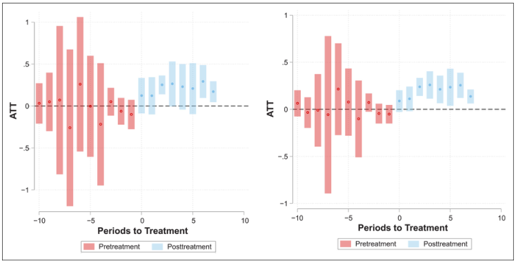

NOTE: figure/graphic rendered as an image from the PDF; its content is not machine-readable text. Caption (if any) follows as the next block.

parameter (λ) were found to have p-values below .05. In particular, we find an increase of 7.818 in average viewers for partnered (vs. nonpartnered) channels on a given day after the policy introduction (Column 1: λ= 7.818, p =.035). Moreover, we show that on a given day after the focal policy introduction, the total hours watched significantly increased by 122.078 hours for partnered channels compared with nonpartnered channels (Column 3: λ= 122.078, p= .003). In terms of percentage change, we find that partnered channels had approximately 9.3% more average viewers (Column 2: λ =.089, p= .014) and 16.3% higher total hours watched (Column 4: λ=.151, p=.001) after the shock, compared with nonpartnered channels.

The effects are large and positive, which suggest substantial revenue and profit implications for streamers, brands, and platforms. Finally, we reran these specifications adding the following controls as a baseline robustness check: (1) the one-period lagged dependent variable and (2) the number of times the channel streamed in each period, recovering similar results (evidence of positive parameters). These results are presented in Web Appendix F. Overall, the results reflect the net effect of the policy, after accounting for any competing forces between ad avoidance and streamer adjustments. These results are also a direct test of RQ1, which asks how the introduction of MRA ability affects live stream viewing behaviors.

#### Addressing Staggered Intervention

Recent studies in the economics literature have introduced new methods to address staggered treatments in DiD estimations. Staggered treatments occur when treated units receive the intervention at different times, which may not generate the correct parameters under TWFE (Roth et al. 2023). Since some

nonpartnered channels may convert to partnered channels (as chosen by the platform) at different times after the main policy introduction, our data setting can be viewed as one with staggered interventions (for a small portion of the data). Callaway and Sant’Anna (2021) (henceforth CS) propose several similar estimators that generate dynamic DiD parameters relative to treatment time. Importantly, a generalized propensity score built on observable covariates is utilized based on each initial treatment period to predict the likelihood of being treated in a given time, thus suggesting that parameters are calculated off of comparable treated and nontreated observations (Callaway and Sant’Anna 2021; Cunningham 2021). We conduct this analysis and present the CS dynamic event study plots for both consumption behaviors (average viewers and hours watched) in Figure 1, Panels A and B, respectively.

The dynamic ATTs from the CS estimates are relative to the initial treatment period. From the figure, we can see that all pre-MRA ability ATTs are near zero, providing continuing support of the parallel trends assumption (all pretreatment ATTs were not notably different from zero). After the intervention, we find low p-values with respect to the CS average ATTs of the policy for both average viewers (ATT = .192, p = .000) and total hours watched (ATT = .207, p = .004), mirroring our TWFE analysis. Details are provided in Web Appendix G.

We also conduct a synthetic difference-in-differences (SDID) analysis (Arkhangelsky et al. 2021). SDID is capable of accounting for the dynamic nature of our DiD setting (like CS) but additionally ensures parallel trends through a reweighting process and, hence, can supplement and reinforce our findings. Similar to the CS findings, the SDID results reveal a clear impact of the intervention on average viewers (avg. ATT = .097, p = .018) and total hours watched (avg. ATT = .074, p =

Figure 1. CS Dynamic DiD Event Study Plots. Notes: Panel A displays the dynamic event study plot for ln(Average Viewers) as the dependent variable, whereas Panel B represents the same plot for ln(Hours Watched). The 95% confidence intervals are displayed. N = 2,507,176 for both CS estimations. The dots in the middle of each bar represent the point estimates.

Page 11

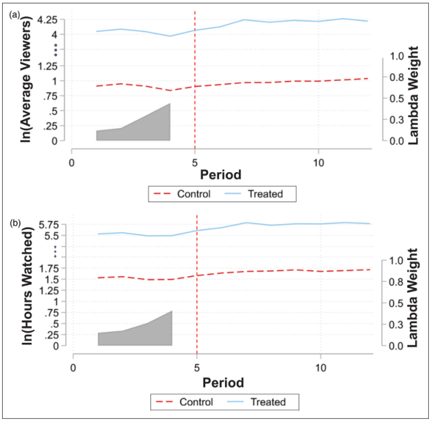

NOTE: figure/graphic rendered as an image from the PDF; its content is not machine-readable text. Caption (if any) follows as the next block.

.033). We present the visualization of SDID results for the first treated cohort in Figure 2, Panels A and B. Additional details of this analysis are discussed in Web Appendix G. As both the CS and SDID results appear to be similar to those using TWFE, we utilize TWFE as our primary method in the remainder of this article.

#### Further Robustness Checks

To provide further support for the main results, we conduct additional robustness checks. First, though the CS estimators also utilize propensity scores, we conduct a standard propensity score matching (PSM) and weighting DiD analysis, similar to that of Ananthakrishnan, Proserpio, and Sharma (2023). Second, we conduct an attrition test using only streamers who streamed in every period. Finally, we also include an analysis to account for the relatively large number of zero values found in the dependent variables. These robustness checks, which can be found in Web Appendix H, all continue to support a positive effect of the intervention on the treated

partnered channels relative to the control group, verifying our initial findings.

#### Addressing Threats to Validity

Coronavirus (COVID-19) pandemic. One concern with our analysis is that the dataset overlaps with the first major wave of the COVID-19 pandemic, which began in March 2020. On March 11, 2020, the World Health Organization declared an official pandemic, which was viewed as the onset of lockdowns and households staying at home (Thebault, Meko, and Alcantara 2021). Thus, one may wonder whether this initial lockdown, and not the focal MRA ability intervention, increased live streaming viewing behaviors for partnered streamers, as lockdowns were implemented close to the introduction of the MRA ability policy (March 17).

We do not believe that COVID-19 is a primary driver of our results for a number of reasons. First, differences between covariates are accounted for through the PSM and CS estimates. For example, COVID-19 lockdowns could have generated

106 Journal of Marketing 90(2)

Page 12

larger audience sizes, and these new viewers may have preferred the content played on partnered channels over nonpartnered ones. Our PSM and CS estimates respond to this threat, as after the matching procedure(s), analysis was conducted on observations with more similar levels of characteristics and observable covariates. Second, our inclusions of FE already account for cross-sectional and time-invariant effects. Third, we find support that the pretreatment trends between groups are parallel (e.g., Figure 1), meaning that other exogenous shocks prior to COVID-19 did not affect the treatment groups differentially. Hence, there is less reason to believe that COVID-19 might also divergently affect partnered channels and nonpartnered ones. In addition, to address the COVID-19 concern more directly, we conducted two empirical tests to provide evidence that the pandemic is unlikely to be a driving factor of our results. We discuss these tests briefly here and provide the full results of both tests in Web Appendix I.

In the first test, we measure the short-term impact of the lockdowns to further show that there is no visible differential effect on consumption behaviors between groups. In particular, since there is a six-day window in which to measure the isolated effect of the lockdowns prior to the MRA ability policy, we run our DiD analysis and use March 11 (the lockdown day) as the “COVID-19 intervention” date to isolate the effect of the initial pandemic lockdown. The results suggest no notable differential impact on consumption for partnered channels in this time frame.

For further assurance, we run a second empirical test, in which we control for potential between-group differential effects of the pandemic lockdowns. Specifically, we leverage data from the World Health Organization, which collected data on daily COVID-19 cases from most countries (World Health Organization 2020). Using the primary language of the streamer to assume audience location, we include the interaction between new daily COVID-19 deaths and the focal term in our DiD analysis to control for differential effects of the pandemic. This analysis is presented in Table W16 of Web Appendix I, and the results continue to indicate a positive focal parameter with regard to both average viewers (Column 1: λ = .046, p = .020) and total hours watched (Column 3: λ = .086, p = .001) despite controlling for the interaction, suggesting that the COVID-19 lockdowns are unlikely to be a driving force in our data setting. Altogether, both tests indicate that the lockdowns were not a prominent factor in our setting.

Testing for potential violation of the stable unit treatment value assumption (interference/spillovers). Next, we address a second threat to validity. Interference (e.g., Johari et al. 2022) could arise due to an overwhelming shift in viewer allurement from the untreated group to the treated group (spillover). Said another way, a viewership spillover between treatment groups would violate the stable unit treatment value assumption, which is required for a DiD analysis. However, we believe this is unlikely to be a focal driver of our results for several reasons. First, PSM considers smaller or moderate streams in order to match partnered observations with nonpartnered ones (for example, the maximum

observation of average viewers was 12,051.6 in the main dataset but only 9,925.3 in the PSM sample). The largest streamers are expected to be the driver of interference since they are the most likely ones siphoning viewers from nonpartnered channels, but our robustness checks with the matching procedures continue to support a positive effect. Second, characteristics are more comparable between the treatment groups after PSM and CS, meaning that there are fewer reasons to prefer one channel over another. Third, streaming audiences who wish to watch several live streams simultaneously can use multiple browser tabs or use websites that enable viewers to watch several streamers on the same screen, and platforms themselves (such as Twitch) offer features enabling audiences to watch multiple streamers concurrently (Robinson 2022). Last, nonpartnered channels do not observe a drastic drop in consumption in the postintervention periods as the interference argument suggests (e.g., Table 1).

For empirical assurance, we ran two sets of analyses to demonstrate that interference (spillover) is unlikely to be a focal driver of our main results. For the first analysis, we reran our DiD analysis but ensured that the primary language used for the treated group observations was different than the control group observations. When using treatment groups with differing languages, evidence of a focal DiD parameter that is still positive would suggest that the effect is due to the MRA ability intervention in isolation and not due to the spillover of nonpartnered viewers switching to partnered viewers, as audience members are far less likely to switch to a stream using a different language than them. The results are presented in Table W17 of Web Appendix I, and we find evidence that our DiD results are still positive.

We ran a second analysis to further combat spillover concerns. As a spillover is concerned with high-performing streamers siphoning viewers from nonpartnered channels and biasing our results, we ran an analysis that (1) removes nonpartnered channels that had a considerable decrease in average viewership between the pre- and postintervention periods and (2) discards the top-performing partnered streamers after the intervention (based on viewership percentile). Running our analysis on this subsample removes the observations that are likely to be impacted by spillover. We continue to find evidence of positive DiD estimates for both consumption variables. The full results of both tests are discussed in Web Appendix I.

#### Mechanism Investigation

Given that we empirically obtain a robust positive effect of MRA ability on consumption behaviors, we argue that ad avoidance is not the focal mechanism behind the observed effects. Instead, we consider whether streamers made any meaningful adjustments that could suggest a net increase in consumption behaviors. Stream airtime, stream frequency, and quality are all proposed to increase as a consequence of streamers adjusting their streaming habits in the hopes of generating higher ad revenue, as it is very common for live streaming platforms to pay streamers through CPM. Ultimately, adjustments are

Wu and Ham 107

Page 13

possible due to the unique nature of live streaming, as streamers have great flexibility in making strategic adjustments (content availability and content quality). We reasonably assume a CPM-based revenue model for streamers in our study (verified with our historical survey), as near the time of our data (2020), other large platforms, including Twitch and YouTube, also ran CPM-based schemes (Kinson 2020). Online news articles also suggest a CPM payment scheme for MRAs in our focal platform. As we previously argued that partnered streamers should make streaming adjustments (irrespective of what nonpartners do), we consider whether partnered streamers increased their airtime, stream frequency, or quality after the intervention. For operationalizations, the time-related mechanism variables used were log-transformed values of airtime and stream frequency (the number of times a channel streamed in a given period). We use ln(NR) as our measure of quality.

Utilizing the same model based on Equation 2 but replacing the dependent variable with each of our mechanism variables, we conduct a formal DiD analysis to explore whether partnered channels made strategic adjustments relative to the control group. The results are presented in Table 4 using the TWFE PSM and weighting approach discussed in Web Appendix H, where we find evidence of a positive effect of the intervention increasing airtime (Column 1: λ = .035, p = .051) and reducing NR (Column 3: λ = −.017, p = .001). We do not find strong statistical evidence of streamers increasing frequency, although the focal parameter is positive. Regarding NR, a negative focal parameter would suggest that streamers reduced their NR and thus increased their quality. Hence, we provide evidence of strategic adjustments by partnered channels, which appeared to have improved their quality by reducing their NR and to have increased their content availability through airtime. Web Appendix J contains details of this analysis, including support for the parallel trends assumption and additional robustness checks (such as using SDID). For verification, we also conduct a formal mediation analysis using the approach suggested by Zhao, Lynch, and Chen (2010). The results support

all three variables as viable mechanisms. Additional details of this analysis are discussed in Web Appendix K.

Our results suggest that partnered streamers adjust their streaming behaviors when MRA ability is introduced primarily through quality improvements (as well as airtime), and that these changes lead to increases in consumption. This make sense for streamers who wish to make a living from live streaming or for those who want to see how successful they can be. Relatedly, our findings suggest that the positive effects of streamer adjustments are stronger than potential negative effects of ad avoidance (creating the overall net positive impact on consumption).

#### Heterogeneity Analysis

Differences by initial streamer success. We conceptually suggested that less successful streamers, after receiving MRA abilities, would be more likely to be incentivized by MRA ad revenue than successful ones (who have other sources of streaming-related income) and would put more effort into making adjustments in their stream. We classify the data into “low,” “moderate,” and “high” success categories in relation to their initial viewership performance in the pretreatment periods. Then we run a separate DiD estimation on each subsample and display the consumption changes in Table 5. Full details and results are shown in Table W22 of Web Appendix L.

From Panel A in Table W22, we note that each group adjusted their strategies differently. First, low-success streamers made aggressive improvements with respect to all three strategic adjustments. Second, moderately successful streamers made more mild or modest adjustments. Finally, high-success streamers only made improvements to quality. Ultimately, all three mechanisms appeared to be viable strategies, but were utilized to various degrees. The results of these adjustments are reflected by the subsample changes in consumption (Panel B in Table W22). It appears that despite differences in their implementations of strategic adjustments, all three groups appeared to receive increases with regard to audience consumption. However, low-success streamers seem to have generated the

Table 4. DiD Focal Mechanism Results.

[output not shown]

NOTE: table converted from PDF layout to HTML text; cell boundaries are reconstructed. See PDF if exact alignment matters.

Notes: The sample size is smaller in the NR analysis due to occasions when average viewers and peak viewers equal zero, which created empty values. The transformation (e<sup>λ</sup> −1) was used for interpretations subsequently in the article. Clustered standard errors are shown in parentheses, while p-values are displayed in square brackets.

108 Journal of Marketing 90(2)

Page 14

largest increases in consumption, while making the most aggressive adjustments. Details of this analysis are found in Web Appendix L.

We note that established low-success streamers could be confounded with new streamers who had high potential with low initial viewership. Thus, we reconducted the analysis using a “no attrition” version of the data, where only channels that streamed in every period (“long-time” streamers) were included, finding similar results.

Established versus late-entry streamers. Next, we explore how established streamers may have implemented strategies differently than newer (late-entry) streamers. To do so, we consider the time of the first appearance of a streaming channel. If a streamer was seen to have streamed for some time prior to the intervention, we considered them established, whereas late-entry streamers were classified as those who first appeared close to the intervention date (or afterward). We run our TWFE DiD analysis based on these subsamples and present the results in Table W23 of Web Appendix M (along with all details). The results suggest that established streamers are the group of streamers that generally make strategic adjustments and receive the bulk of the increases in consumption.

Solo versus social content. We next investigate whether the sociability of the content activity shown in a stream affects the impact of the focal MRA ability policy. To that end, we organize observations by content activities. We classify content activities into one of three general categories: solo (independent activities), social (multiperson activities), or activities that can be both solo and social. Then, we run our DiD analysis on each subsample and present the summarized results in Table 6. Interestingly, our analysis suggests that positive increases in audience consumption after the focal policy implementation for the treated group were found primarily in content activities that included social contact outside of interactions between the streamer and the audience. This analysis is detailed in Web Appendix N.

Individualistic versus collectivist streamers and audiences. Next, we consider whether the main effect differs for audiences that are individualistic versus collectivist. We classify languages into individualistic or collectivist nations, utilizing streaming language to assume the location of the streamer and the audience. Using our subsample analysis approach, we report the full analysis in Table W25 of Web Appendix O. The results suggest that while both individualistic and collectivist streamers are exposed to consumption improvements after receiving MRA abilities, streamers from collectivist countries receive even greater increases in consumption. Details are found in Web Appendix O.

Treatment effect across time. A final consideration is whether the MRA ability intervention maintained persistent effects across time. Fortuitously, the previously conducted CS analysis calculates the dynamic ATTs across time for our data relative to the first treatment period. From Table W8 in Web Appendix G, we can see that the increases in viewership do not occur immediately (in the first treatment period). After one or two periods from treatment, the ATTs become positive, suggesting that the consumption effects of the policy work only after some time has passed. We find evidence that the positive effects generally increase, peak, and eventually decrease in magnitude (seven weeks after initial treatment). This pattern is visually reflected in Figure 1, Panels A and B. The initial gradual adjustment is consistent with our historical survey, which indicated that streamers may briefly delay playing MRAs after receiving MRA abilities. Furthermore, streamers may vary in the speed with which they implement strategic adjustments (quickly or slowly), potentially further contributing to this pattern. Finally, it appears that the effects of the MRA policy begin to waver to some degree approximately seven weeks after the initial treatment week, indicating that streamer adjustments may eventually be met with diminishing marginal returns.

#### Verification Survey

Last, we conducted a verification survey to corroborate our core findings. This survey adds to our secondary data research because we were unable to observe whether streamers played

Table 6. DiD Parameter Estimates by Content Activity Type.

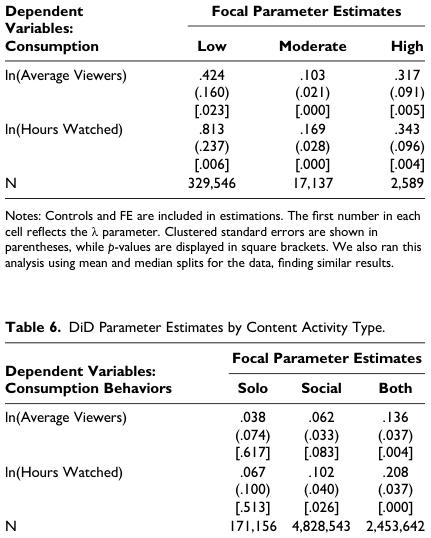

NOTE: complex table shown as an image of the PDF; the text below is a rough machine extraction and may be mis-aligned.

**extracted text (unreliable layout)**

Notes: Controls and FE are included in estimations. The first number in each cell reflects the λ parameter. Clustered standard errors are shown in parentheses, while p-values are displayed in square brackets.

Table 5. DiD Parameter Estimates by Initial Viewership.

Wu and Ham 109

Page 15

MRAs when given the option to do so (though the historical survey suggests that at least a reasonable proportion did play MRAs). Respondents were asked to imagine that they were live streamers who previously could not play ads and were suddenly granted MRA abilities, and that they could make ad revenue for every individual who views the MRA. We then asked about their resultant behaviors. We ran a pretest on students drawn from a large U.S. university (N = 127) and then sent the main survey to real live streamers (N = 85). A summary of the results is shown in Table 7. We find that 77.65% of live streamers surveyed indicated that generating ad revenue would be important to them and 70.59% would adjust their behavior to mitigate ad avoidance. These results are consistent with our secondary data findings and show that ad incentives should entice streamers to play MRAs and make adjustments. Also, most streamers (51.76%) would increase either frequency, airtime, quality, or effort, as we proposed.

Finally, the verification survey included a section where we asked respondents to write any additional thoughts on MRA usage (if they had any). This enabled us to recover bodies of text (roughly) detailing additional strategies on how individuals might wish to implement MRAs. To explore this information, we turned to the machine learning approach of latent Dirichlet allocation, which clusters bodies of text into topics based on the notion that similar topics are likely to use the same words (Berger et al. 2020). For simplicity, we searched for two topics. Examples of top words found in the first topic were “content,” “comedic,” and “enjoy.” Top words in the second topic included “bathroom,” “water,” “breaks,” and “food.” Based on these words, we note that the first topic is related to the ad content, where streamers would prefer to play humorous or enjoyable ads for the audience. The second topic focuses on timing, as streamers wish to play ads when no true content is occurring, for example, during a restroom or snack break. These associations indicate that streamers wish to strategically plan how to use MRAs and that there could be ways to implement these ads while minimizing backlash. Though exploratory, these results reveal additional strategies on how streamers might play MRAs. Details of this survey

and the latent Dirichlet allocation procedure are provided in Web Appendix P.

#### Managerial Implications

Our findings carry actionable implications for platforms, streamers, and brands. The baseline results from this study (Table 3) suggest a 9.3% increase in average viewership and a 16.3% increase in total hours watched for partnered channels (compared with the control), which improves platform traffic and ad exposure. Based on our projections (Web Appendix Q), streamers generate roughly $115.92 of additional income per week from playing MRAs. Since MRAs can increase viewership and do not displace streamer revenues from other sources (noted in the historical survey), platforms, streamers, and brands should be receptive to MRAs because MRAs can substantially benefit each entity. More specifically, platforms can command higher impressions, brands could display their products to a larger audience, and streamers are compensated for increased viewership.

For platforms, although the increase in content consumption from MRAs is through streamer adjustments (more than half the streamers in our survey indicated this), which occur primarily through improvements in both airtime (3.6% increase) and quality (1.7% reduction in NR), the effects of MRAs are heterogeneous. The largest relative increases in content consumption occurred for low-success streamers (gains of 52.8% in viewership and 125.5% in hours watched), established channels (gain of 9.3% in viewership and 16.1% in hours watched), content with a multiplayer component (improvements of 6.4% in viewership and 10.7% in hours watched), and collectivist markets over individualistic ones (in comparison, collectivist markets experience increases of 12.4% in viewership and 19.8% in hours watched). Hence, platforms should grant ads to streamers who have the personality or willingness to make adjustments to airtime and quality. In addition, platforms may wish to consider providing bonus incentives for streamers who acquire high levels of ad exposure, particularly if they are found to be engaging with viewer segments that were not expected to generate sufficient ad exposure (such as solo

Table 7. Summary of Verification Survey Responses.

[output not shown]

NOTE: table converted from PDF layout to HTML text; cell boundaries are reconstructed. See PDF if exact alignment matters.

Notes: The questions are abridged in this table. Full details are presented in Web Appendix P.

110 Journal of Marketing 90(2)

Page 16

content streamers or those in individualistic countries). Last, platforms should seek brands that complement the content of the stream, as suggested by the surveys.

Streamers, meanwhile, should carefully examine their ad and adjustment strategies. First, streamers should be aware of how likely their strategic adjustments are to drive improvements in viewership. For instance, if a streamer is a low-success streamer, they can gain the most by implementing strategic adjustments from MRAs. Second, streamers should try to make strategic adjustments as quickly as possible since our results indicate that the benefits of streamer adjustments from MRAs may decline over time. Finally, the content of the stream and the timing of the MRAs could matter in terms of audience receptiveness. Streamers should focus on social content over solo content and can use the ads for natural breaks (as noted from the surveys).

Brands should consider partnering with social content streamers—for instance, sending free items like clothing or computer equipment for the streamers to use while broadcasting—as they are expected to have higher levels of ad exposure than streamers of solo content. Additionally, our survey suggests that viewers may appreciate comedic or enjoyable ads, so firms should consider creating humorous or entertaining ads. Furthermore, brands may wish to consider experimenting with the types of ads utilized in ad-tolerant categories, such as streamers playing social content in collectivist markets, using A/B testing to explore which ad campaigns may prove to be superior.

Finally, we explore the financial impact of the MRA ability policy by leveraging information from both the historical survey and our DiD results. The calculation details of these projections are in Web Appendix Q. As previously mentioned, streamers

made around $115.92 of income per week for playing MRAs. From a revenue lift perspective, approximately $7.36 of additional income per week was made by a streamer who increased their viewership, compared with one who did not. Next, streamers who played content in the “both” category (solo and social) received an extra $11.04 per week over streamers playing solo content. Furthermore, the platform itself gained $105,811.78 per week by giving MRA abilities to partnered streamers. We summarize the main findings and actionable managerial recommendations in Table 8.

#### Conclusion and Limitations

This research uses a panel dataset of a live streaming platform in 2020 and a DiD estimation approach to study a policy intervention that introduced the ability to play MRAs. We find evidence of positive effects of MRA abilities on live streaming consumption behaviors, which is surprising, because ad avoidance suggests that ads are typically not desired (RQ1). We then provide evidence in support of increases in airtime, number of streaming sessions (to some degree), and quality for partnered channels after the shock, underpinning a key mechanism behind the increase in consumption behaviors (RQ2). Conceptually, this increase can be explained by partnered streamers putting forth greater effort by increasing their airtime, frequency, or quality to garner MRA revenues (to increase ad exposure). Finally, we explored the heterogeneity within these findings, providing evidence that (1) low-success streamers made more aggressive adjustments to quality than more successful streamers, (2) established streamers made more drastic adjustments than those who entered later, (3) content that contains some degree of social interaction

Table 8. Summary of Research Findings and Actionable Recommendations.

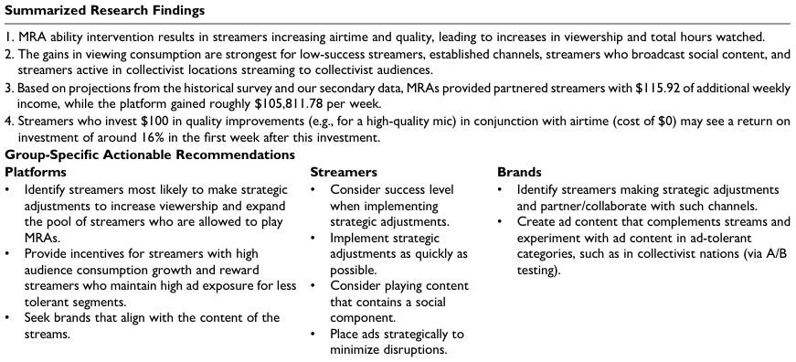

NOTE: complex table shown as an image of the PDF; the text below is a rough machine extraction and may be mis-aligned.

**extracted text (unreliable layout)**

Wu and Ham 111

Page 17

appears to generate the largest consumption increases, (4) collectivist streamers benefited more than individualistic ones, and (5) the MRA policy effects appear to manifest in an inverted U-shaped curve across time (RQ3). We then provide further support of the first two RQs with our verification survey.

We note several limitations. First, our secondary data do not include streamers’ usage of MRAs. We only observe that the streamer has the ability to use MRAs, and because of the benefits of this ability, we assume that MRAs are implemented (although we provide support for this through our two surveys). Relatedly, we also do not comment on how nuances such as targeting or time of day may play a role (e.g., Kanuri, Chen, and Sridhar 2018). Second, we do not focus on how MRAs affect brand consumption. Third, this study does not examine how varying levels of MRA advertising intensity may have varying effects. Fourth, even though we attempt to curb the impact of the COVID-19 pandemic in our data via multiple empirical tests, COVID-19 concerns remain an important limitation of our data setting.

Coeditor

Detelina Marinova

Associate Editor

Raj Venkatesan

Declaration of Conflicting Interests

The author(s) declared no potential conflicts of interest with respect to the research, authorship, and/or publication of this article.

Funding

The author(s) disclosed receipt of the following financial support for the research, authorship, and/or publication of this article: This work was supported by the Eli Broad College of Business Summer Research Grant.

ORCID iDs

Michael W. Wu https://orcid.org/0009-0005-8200-4228 Sung H. Ham https://orcid.org/0000-0002-9744-5828

References

Ananthakrishnan, Uttara, Davide Proserpio, and Siddhartha Sharma

(2023), “I Hear You: Does Quality Improve with Customer Voice?” Marketing Science, 42 (6), 1143–61. Angrist, Joshua D. and Jörn-Steffen Pischke (2009), Mostly Harmless

Econometrics: An Empiricist’s Companion. Princeton University Press. Arkhangelsky, Dmitry, Susan Athey, David A. Hirshberg, Guido

W. Imbens, and Stefan Wager (2021), “Synthetic Differencein-Differences,” American Economic Review, 111 (12), 4088–118. Berger, Jonah, Ashlee Humphreys, Stephan Ludwig, Wendy W. Moe,

Oded Netzer, and David A. Schweidel (2020), “Uniting the Tribes: Using Text for Marketing Insight,” Journal of Marketing, 84 (1), 1–25. Berger, Jonah and Katherine L. Milkman (2012), “What Makes Online

Content Viral?” Journal of Marketing Research, 49 (2), 192–205.

Bertrand, Marianne, Esther Duflo, and Sendhil Mullainathan (2004),

“How Much Should We Trust Difference-in-Difference Estimates?” Quarterly Journal of Economics, 119 (1), 249–75. Bromiley, Philip (1991), “Testing a Causal Model of Corporate Risk

Taking and Performance,” Academy of Management Journal, 34 (1), 37–59. Butler, Ricky Ray (2021), “Going Live Online: The State of Live

Streaming and the Opportunities for Brands,” Forbes (February 4), https://www.forbes.com/sites/forbesagencycouncil/2021/02/04/ going-live-online-the-state-of-live-streaming-and-the-opportunitiesfor-brands/. Callaway, Brantly and Pedro H.C. Sant’Anna (2021), “Difference-in-Differences with Multiple Time Periods,” Journal of Econometrics, 225 (2), 200–230. Chae, Inyoung, Hernán A. Bruno, and Fred M. Feinberg (2019),

“Wearout or Weariness? Measuring Potential Negative Consequences of Online Ad Volume and Placement on Website Visits,” Journal of Marketing Research, 56 (1), 57–75. China, Chrystal R. (2024), “What Is Live Streaming?” IBM (December

4), https://www.ibm.com/think/topics/live-streaming. Cho, Chang-Hoan and Hongsik John Cheon (2004), “Why Do People

Avoid Advertising on the Internet?” Journal of Advertising, 33 (4), 89–97. Correia, Sergio (2014), “REGHDFE: Stata Module to Perform Linear

or Instrumental-Variable Regression Absorbing Any Number of High-Dimensional Fixed Effects,” Statistical Software Components S457874, Boston College Department of Economics, https://ideas.repec.org/c/boc/bocode/s457874.html. Cunningham, Scott (2021), “Callaway and Sant’anna DD Estimator: A

Story of Differential Timing and Heterogeneity,” Substack (March 8), https://causalinf.substack.com/p/callaway-and-santanna-dd-estimator. D’Anastasio, Cecilia (2022), “Amazon’s Twitch Seeks to Revamp

Creator Pay with Focus on Profit,” Bloomberg (April 27), https:// www.bloomberg.com/news/articles/2022-04-27/amazon-s-twitchseeks-to-revamp-creator-pay-with-focus-on-profit. Datta, Hannes, George Knox, and Bart J. Bronnenberg (2018),

“Changing Their Tune: How Consumers’ Adoption of Online Streaming Affects Music Consumption and Discovery,” Marketing Science, 37 (1), 5–21. Fader, Peter S. and Russell S. Winer (2012), “Introduction to the

Special Issue on the Emergence and Impact of User-Generated Content,” Marketing Science, 31 (3), 369–71. Fisher, Marshall L., Santiago Gallino, and Joseph Jiaqi Xu (2019),

“The Value of Rapid Delivery in Omnichannel Retailing,” Journal of Marketing Research, 56 (5), 732–48. Fossen, Beth L. and David A. Schweidel (2019), “Social TV,

Advertising, and Sales: Are Social Shows Good for Advertisers?” Marketing Science, 38 (2), 274–95. Gill, Manpreet, Shrihari Sridhar, and Rajdeep Grewal (2017), “Return

on Engagement Initiatives: A Study of a Business-to-Business Mobile App,” Journal of Marketing, 81 (4), 45–66. Goldfarb, Avi, Catherine Tucker, and Yanwen Wang (2022),

“Conducting Research in Marketing with Quasi-Experiments,” Journal of Marketing, 86 (3), 1–20. Grayson, Nathan (2021), “The Twitch Hack Revealed Much More

Than Streamer Salaries. Here Are 4 New Takeaways,”

112 Journal of Marketing 90(2)

Page 18

Washington Post (October 8), https://www.washingtonpost.com/ video-games/2021/10/08/twitch-hack-leak-minimum-wage-payhasan/. Grayson, Nathan (2022), “Twitch Ad Update Offers Some Streamers

Big Money, Others Pocket Change,” Washington Post (June 20), https://www.washingtonpost.com/video-games/2022/06/20/twitchad-incentive-money-payout-55-percent/. Haenlein, Michael, Ertan Anadol, Tyler Farnsworth, Harry Hugo,

Jess Hunichen, and Diana Welte (2020), “Navigating the New Era of Influencer Marketing: How to Be Successful on Instagram, TikTok, & Co.,” California Management Review, 63 (1), 5–25. Hart, Robert (2021), “Video and Live Streaming Apps Are Fueling a

New Social Media Boom,” Forbes (September 6), https://www. forbes.com/sites/roberthart/2021/09/06/video-and-live-streamingapps-are-fueling-a-new-social-media-boom/?sh=6c3c29657781. Hennig-Thurau, Thorsten and Alexander Klee (1997), “The Impact of

Customer Satisfaction and Relationship Quality on Customer Retention: A Critical Reassessment and Model Development,” Psychology & Marketing, 14 (8), 737–64. Hennig-Thurau, Thorsten, Caroline Wiertz, and Fabian Feldhaus

(2015), “Does Twitter Matter? The Impact of Microblogging Word of Mouth on Consumers’ Adoption of New Movies,” Journal of the Academy of Marketing Science, 43, 375–94. Hilvert-Bruce, Zorah, James T. Neill, Max Sjöblom, and Juho Hamari

(2018), “Social Motivations of Live-Streaming Viewer Engagement on Twitch,” Computers in Human Behavior, 84, 58–67. Hofstede, Geert (1983), “The Cultural Relativity of Organizational

Practices and Theories,” Journal of International Business Studies, 14, 75–90. Hoopes, David G., Tammy L. Madsen, and Gordon Walker (2003),

“Guest Editors’ Introduction to the Special Issue: Why Is There a Resource-Based View? Toward a Theory of Competitive Heterogeneity,” Strategic Management Journal, 24 (10), 889–902. Hu, Mu, Mingli Zhang, and Yu Wang (2017), “Why Do Audiences

Choose to Keep Watching on Live Video Streaming Platforms? An Explanation of Dual Identification Framework,” Computers in Human Behavior, 75, 594–606. Janakiraman, Ramkumar, Joon Ho Lim, and Rishika Rishika (2018),

“The Effect of a Data Breach Announcement on Customer Behavior: Evidence from a Multichannel Retailer,” Journal of Marketing, 82 (2), 85–105. Johari, Ramesh, Hannah Li, Inessa Liskovich, and Gabriel Y. Weintraub

(2022), “Experimental Design in Two-Sided Platforms: An Analysis of Bias,” Management Science, 68 (10), 7069–89. Kanuri, Vamsi K., Yixing Chen, and Shrihari (Hari) Sridhar (2018),

“Scheduling Content on Social Media: Theory, Evidence, and Application,” Journal of Marketing, 82 (6), 89–108. Kim, Tongil “TI” and Diwas KC (2020), “Can Viagra Advertising Make

More Babies? Direct-to-Consumer Advertising on Public Health Outcomes,” Journal of Marketing Research, 57 (4), 599–616. Kinson, Anthony (2020), “Streaming Platform Comparison: Partner vs

Affiliate,” Gamesight (July 30), https://blog.gamesight.io/partnervs-affliate/. Kozlenkova, Irina V., Stephen A. Samaha, and Robert W. Palmatier

(2014), “Resource-Based Theory in Marketing,” Journal of the Academy of Marketing Science, 42, 1–21.

Lamberton, Cait and Andrew T. Stephen (2016), “A Thematic

Exploration of Digital, Social Media, and Mobile Marketing: Research Evolution from 2000 to 2015 and an Agenda for Future Inquiry,” Journal of Marketing, 80 (6), 146–72. Lee, Dokyun, Kartik Hosanagar, and Harikesh S. Nair (2018),

“Advertising Content and Consumer Engagement on Social Media: Evidence from Facebook,” Management Science, 64 (11), 5105–31. Leung, Fine, Flora Gu, Yiwei Li, Jonathan Z. Zhang, and Robert Palmatier (2022), “Influencer Marketing Effectiveness,” Journal of Marketing, 86 (6), 93–115. Lin, Yan, Dai Yao, and Xingyu Chen (2021), “Happiness Begets

Money: Emotion and Engagement in Live Streaming,” Journal of Marketing Research, 58 (3), 417–38. Llonch, Enric (2021), “Twitch Marketing: How to Develop Your

Strategy,” Cyberclick (September 3), https://www.cyberclick.net/ numericalblogen/twitch-marketing-how-to-develop-your-strategy. Lu, Shijie, Dai Yao, Xingyu Chen, and Rajdeep Grewal (2021), “Do

Larger Audiences Generate Greater Revenues Under Pay What You Want? Evidence from a Live Streaming Platform,” Marketing Science, 40 (5), 964–84. Madsen, Tammy L. and Gordon Walker (2017), “Competitive

Heterogeneity, Cohorts, and Persistent Advantage,” Strategic Management Journal, 38 (2), 184–202. Manchanda, Puneet, Jean-Pierre Dubé, Khim Yong Goh, and Pradeep

K. Chintagunta (2006), “The Effect of Banner Advertising on Internet Purchasing,” Journal of Marketing Research, 43 (1), 98–108. Miceli, Max (2021), “What Is Twitch Turbo?” Dot Esports (October

13), https://dotesports.com/streaming/news/what-is-twitch-turbo. Morales, Andrea C. (2005), “Giving Firms an ‘E’ for Effort: Consumer

Responses to High-Effort Firms,” Journal of Consumer Research, 31 (4), 806–12. Munson, Ben (2018), “YouTube Premium Arrives to Take on Hulu and

Spotify,” StreamTV Insider (June 19), https://www.streamtvinsider. com/video/youtube-premium-arrives-to-take-hulu-and-spotify. Needleman, Sarah E. (2020), “Everyone Is a Live-Streamer in Covid-19

Era,” Wall Street Journal (August 9), https://www.wsj.com/articles/ everyone-is-a-live-streamer-in-covid-19-era-11596965400. Obloj, Tomasz and Laurence Capron (2011), “Role of Resource Gap and

Value Appropriation: Effect of Reputation Gap on Price Premium in Online Auctions,” Strategic Management Journal, 32 (4), 447–56. Park, Eunho, Rishika Rishika, Ramkumar Janakiraman, Mark B. Houston, and Byungjoon Yoo (2018), “Social Dollars in Online Communities: The Effect of Product, User, and Network Characteristics,” Journal of Marketing, 82 (1), 93–114. Parrish, Ash (2022), “Twitch Expands Ad Programs to Pay Streamers

More Money,” Verge (June 14), https://www.theverge.com/2022/6/ 14/23168185/twitch-ad-incentive-program-payouts-increase-1-billionstreamer-revenue. Perlberg, Steven (2017), “Facebook to Test Mid-Roll Video Ads,”

Wall Street Journal (January 9), https://www.wsj.com/articles/ facebook-to-test-mid-roll-video-ads-1483996638. Peteraf, Margaret A. (1993), “The Cornerstones of Competitive

Advantage: A Resource-Based View,” Strategic Management Journal, 14 (3), 179–91.

Wu and Ham 113

Page 19

Porter, Constance Elise and Naveen Donthu (2008), “Cultivating Trust

and Harvesting Value in Virtual Communities,” Management Science, 54 (1), 113–28. Robinson, Mika (2022), “How to Watch Multiple Twitch Streams at

Once,” Stream Labs (May 25), https://streamlabs.com/contenthub/post/how-to-watch-multiple-twitch-streams-at-once. Roth, Jonathan, Pedro H.C. Sant’Anna, Alyssa Bilinski, and John Poe

(2023), “What’s Trending in Difference-in-Differences? A Synthesis of the Recent Econometrics Literature,” Journal of Econometrics, 235 (2), 2218–44. Rubio-Licht, Nat (2022), “Twitch Wants Streamers to Make a Steady

Paycheck,” Protocol (February 23), https://web.archive.org/web/ 20230609011131/https://www.protocol.com/bulletins/twitch-adsincentive-program. Samaha, Stephen A., Joshua T. Beck, and Robert W. Palmatier (2014),

“The Role of Culture in International Relationship Marketing,” Journal of Marketing, 78 (5), 79–98. Shevenock, Sarah and Alyssa Meyers (2021), “Consumers Think

Streaming Ads Are Repetitive and Invasive. The Industry Says It’s Fixing It,” Morning Consult (October 18), https:// morningconsult.com/2021/10/18/ad-tech-streaming-services-poll/. Sridhar, Shrihari, Murali K. Mantrala, Prasad A. Naik, and Esther Thorson (2011), “Dynamic Marketing Budgeting for Platform Firms: Theory, Evidence and Application,” Journal of Marketing Research, 48 (6), 929–43.

Thebault, Reis, Tim Meko, and Junne Alcantara (2021), “Sorrow and

Stamina, Defiance and Despair. It’s Been a Year,” Washington Post (March 11), https://www.washingtonpost.com/nation/ interactive/2021/coronavirus-timeline/. Van Doorn, Jenny and Janny C. Hoekstra (2013), “Customization of

Online Advertising: The Role of Intrusiveness,” Marketing Letters, 24, 339–51. Wan, William P., Robert E. Hoskisson, Jeremy C. Short, and Daphne

W. Yiu (2011), “Resource-Based Theory and Corporate Diversification: Accomplishments and Opportunities,” Journal of Management, 37 (5), 1335–68. Whitler, Kimberly A. (2022), “Super Bowl Ads Provide Hollywood-

Sized Entertainment,” Forbes (February 13), https://www.forbes. com/sites/kimberlywhitler/2022/02/13/super-bowl-ads-providehollywood-sized-entertainment/. Wilbur, Kenneth C. (2008), “A Two-Sided, Empirical Model of Television

Advertising and Viewing Markets,” Marketing Science, 27 (3), 356–78. Wilbur, Kenneth C., Linli Xu, and David Kempe (2013), “Correcting

Audience Externalities in Television Advertising,” Marketing Science, 32 (6), 892–912. World Health Organization (2020), “WHO Coronavirus (COVID-19)

Dashboard,” (accessed April 22, 2023), https://covid19.who.int/data. Zhao, Xinshu, John G. Lynch Jr., and Qimei Chen (2010), “Reconsidering

Baron and Kenny: Myths and Truths About Mediation Analysis,” Journal of Consumer Research, 37 (2), 197–206.

114 Journal of Marketing 90(2)

Page 20